# PCIT-CoS-Waitlist RCT Paper 1: ECBI

Nancy Briggs

26 May 2022

### BCAP

#### Descriptives

##### BCAP Risk descriptives

| group | time | n | mean | sd | median | min | max |
| --- | --- | --- | --- | --- | --- | --- | --- |
| 1 | 1 | 29 | 5.827586 | 4.826038 | 4.0 | 2 | 17 |
| 1 | 2 | 23 | 4.695652 | 3.322578 | 3.0 | 2 | 14 |
| 1 | 3 | 16 | 5.937500 | 5.335026 | 3.0 | 2 | 18 |
| 2 | 1 | 28 | 7.857143 | 5.454962 | 6.5 | 2 | 21 |
| 2 | 2 | 11 | 7.636364 | 4.945154 | 5.0 | 3 | 16 |
| 2 | 3 | 4 | 6.000000 | 5.477226 | 4.0 | 2 | 14 |
| 3 | 1 | 24 | 6.916667 | 4.735772 | 5.0 | 2 | 17 |
| 3 | 2 | 19 | 5.894737 | 3.970653 | 4.0 | 2 | 16 |
| 3 | 3 | 0 | NaN | NA | NA | Inf | -Inf |

##### BCAP Lie descriptives

| group | time | n | mean | sd | median | min | max |
| --- | --- | --- | --- | --- | --- | --- | --- |
| 1 | 1 | 30 | 3.100000 | 1.729062 | 3 | 0 | 6 |
| 1 | 2 | 23 | 2.826087 | 1.266784 | 3 | 0 | 5 |
| 1 | 3 | 18 | 2.777778 | 1.699673 | 3 | 0 | 6 |
| 2 | 1 | 27 | 3.407407 | 1.646891 | 4 | 0 | 6 |
| 2 | 2 | 13 | 4.153846 | 1.573009 | 5 | 1 | 6 |
| 2 | 3 | 4 | 2.000000 | 1.825742 | 2 | 0 | 4 |
| 3 | 1 | 26 | 3.346154 | 1.521639 | 3 | 0 | 6 |
| 3 | 2 | 21 | 2.904762 | 1.480026 | 3 | 0 | 5 |
| 3 | 3 | 0 | NaN | NA | NA | Inf | -Inf |

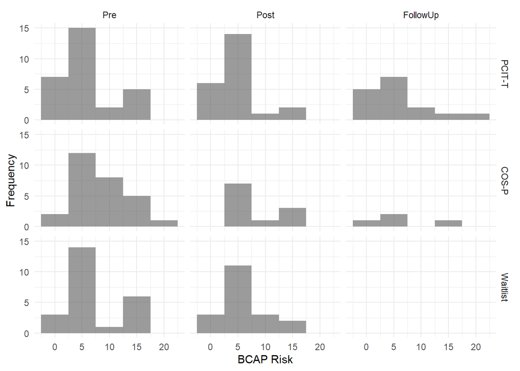

#### Model & Results

A linear mixed model with random effect for individual and fixed effects of group, time and the interaction was run. Estimated marginal means were obtained, and contrasts specified to test Hypothesis 1 and Hypothesis 2.

```
## fixed-effect model matrix is rank deficient so dropping 1 column / coefficient
```

```
## fixed-effect model matrix is rank deficient so dropping 1 column / coefficient
```

```
## refitting model(s) with ML (instead of REML)
```

|  | Effect | npar | AIC | BIC | logLik | deviance | Chisq | Df | Pr(>Chisq) |
| --- | --- | --- | --- | --- | --- | --- | --- | --- | --- |
| result0 | Intercept | 3 | 847.1388 | 856.2301 | -420.5694 | 841.1388 | NA | NA | NA |
| result0_5 |  | 4 | 832.7580 | 844.8798 | -412.3790 | 824.7580 | 16.380709 | 1 | 0.0000518 |
| result1 |  | 6 | 833.9734 | 852.1560 | -410.9867 | 821.9734 | 2.784622 | 2 | 0.2485003 |
| result2 |  | 8 | 832.6750 | 856.9185 | -408.3375 | 816.6750 | 5.298469 | 2 | 0.0707053 |
| result3 |  | 11 | 837.1345 | 870.4693 | -407.5673 | 815.1345 | 1.540442 | 3 | 0.6729683 |

```r
result <- as(result3,"merModLmerTest")
print(summary(result,ddf="Satterthwaite"),correlation=FALSE)
```

```
## Linear mixed model fit by REML. t-tests use Satterthwaite's method [
## lmerModLmerTest]
## Formula: outcome ~ lie + group * time + (1 | id)
##    Data: dat
##
## REML criterion at convergence: 805.4
##
## Scaled residuals:
##      Min       1Q   Median       3Q      Max
## -3.03313 -0.39573 -0.08932  0.38026  2.93103
##
## Random effects:
##  Groups   Name        Variance Std.Dev.
##  id       (Intercept) 14.394   3.794
##  Residual              4.735   2.176
## Number of obs: 153, groups:  id, 84
##
## Fixed effects:
##              Estimate Std. Error       df t value Pr(>|t|)
## (Intercept)    3.3737     1.0483 128.3195   3.218 0.001633 **
## lie            0.7679     0.2153 141.6368   3.567 0.000492 ***
## group2         2.0095     1.1588  97.1817   1.734 0.086069 .
## group3         1.0052     1.1867  98.5500   0.847 0.399014
## time2         -0.4768     0.6429  67.2960  -0.742 0.460908
## time3          0.1366     0.7483  69.7812   0.183 0.855697
## group2:time2  -0.8769     1.1442  76.5219  -0.766 0.445791
## group3:time2  -0.8849     0.9667  68.4932  -0.915 0.363213
## group2:time3  -1.3210     1.5839  73.3379  -0.834 0.407002
## ---
## Signif. codes:  0 '***' 0.001 '**' 0.01 '*' 0.05 '.' 0.1 ' ' 1
## fit warnings:
## fixed-effect model matrix is rank deficient so dropping 1 column / coefficient
```

#### Estimated Means & Change

Estimated means for each Treatment and Time are presented. In addition, within-group change between time points is presented with 95% CIs.

##### Group mean difference at each timepoint

Effect sizes all calculated by the pooled T1 SD of the outcome. Adjusted p-value from Bonferroni correction.

Group Differences at Each Time Point

| Group Difference | Time | Mean | SE | t | p | adj p | Lower CL | Upper CL | Effect Size | Lower CL | Upper CL |
| --- | --- | --- | --- | --- | --- | --- | --- | --- | --- | --- | --- |
| 1 - 2 | 1 | -2.010 | 1.159 | -1.734 | 0.198 | 0.258 | -4.768 | 0.749 | -0.390 | -1.001 | 0.008 |
| 1 - 3 | 1 | -1.005 | 1.187 | -0.847 | 0.675 | 1.000 | -3.829 | 1.819 | -0.195 | -0.761 | 0.392 |
| 2 - 3 | 1 | 1.004 | 1.208 | 0.831 | 0.685 | 1.000 | -1.871 | 3.879 | 0.195 | -0.267 | 0.831 |
| 1 - 2 | 2 | -1.133 | 1.402 | -0.808 | 0.699 | 1.000 | -4.454 | 2.189 | -0.220 | -1.053 | 0.129 |
| 1 - 3 | 2 | -0.120 | 1.256 | -0.096 | 0.995 | 1.000 | -3.103 | 2.862 | -0.023 | -0.583 | 0.535 |
| 2 - 3 | 2 | 1.012 | 1.448 | 0.699 | 0.765 | 1.000 | -2.420 | 4.445 | 0.197 | -0.161 | 1.076 |
| 1 - 2 | 3 | -0.689 | 1.771 | -0.389 | 0.920 | 1.000 | -4.885 | 3.508 | -0.134 | -0.712 | 0.761 |
| 1 - 3 | 3 | NA | NA | NA | NA | NA | NA | NA | NA | NA | NA |
| 2 - 3 | 3 | NA | NA | NA | NA | NA | NA | NA | NA | NA | NA |

* Effect size scaled by pooled T1 SD  
† ES 95% Bootstrapped Percentile CI limits  
‡ If you want a positive ES (and it is calculated as negative), be sure to switch the signs and positions of the lower and upper CIs.

##### Change within each group

Within-Group Change and Effect Sizes

| Change | Group | Mean | SE | t | p | adj p | Lower CL | Upper CL | Effect Size | Lower CL | Upper CL |
| --- | --- | --- | --- | --- | --- | --- | --- | --- | --- | --- | --- |
| 1 - 2 | 1 | 0.477 | 0.644 | 0.740 | 0.740 | 1.000 | -1.066 | 2.020 | 0.093 | -0.097 | 0.416 |
| 1 - 3 | 1 | -0.137 | 0.750 | -0.182 | 0.982 | 1.000 | -1.932 | 1.659 | -0.027 | -0.214 | 0.395 |
| 2 - 3 | 1 | -0.613 | 0.748 | -0.820 | 0.692 | 1.000 | -2.406 | 1.179 | -0.119 | -0.381 | 0.224 |
| 1 - 2 | 2 | 1.354 | 0.940 | 1.441 | 0.325 | 0.461 | -0.890 | 3.598 | 0.263 | -0.200 | 0.519 |
| 1 - 3 | 2 | 1.184 | 1.441 | 0.822 | 0.690 | 1.000 | -2.257 | 4.626 | 0.230 | 0.020 | 1.206 |
| 2 - 3 | 2 | -0.169 | 1.515 | -0.112 | 0.993 | 1.000 | -3.787 | 3.449 | -0.033 | -0.160 | 0.998 |
| 1 - 2 | 3 | 1.362 | 0.731 | 1.864 | 0.157 | 0.199 | -0.387 | 3.111 | 0.265 | 0.068 | 0.603 |
| 1 - 3 | 3 | NA | NA | NA | NA | NA | NA | NA | NA | NA | NA |
| 2 - 3 | 3 | NA | NA | NA | NA | NA | NA | NA | NA | NA | NA |

* Effect size scaled by pooled T1 SD  
† ES 95% Bootstrapped Percentile CI limits  
‡ If you want a positive ES (and it is calculated as negative), be sure to switch the signs and positions of the lower and upper CIs.

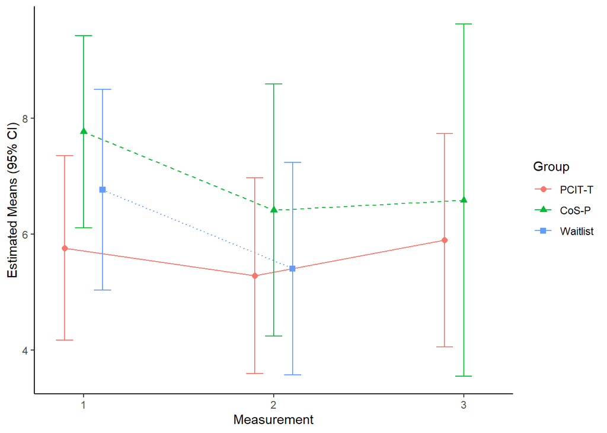

#### Hypothesis 1

We hypothesize that from baseline (‘T1’) to post-treatment/waitlist (‘T2’) there will be a gradient effect, whereby parent-child dyads who receive PCIT-T will show the greatest gains and parent-child dyads who receive no treatment will show the least gains. For the outcome, then, the null hypothesis is:

This is a joint hypothesis test.

First, confirming that the ordering of the changes is as hypothesized:

```
## group = 1:
##  contrast estimate    SE   df t.ratio p.value
##  1 - 2       0.477 0.644 68.0   0.740  0.7404
##  1 - 3      -0.137 0.750 70.5  -0.182  0.9819
##  2 - 3      -0.613 0.748 66.5  -0.820  0.6919
##
## group = 2:
##  contrast estimate    SE   df t.ratio p.value
##  1 - 2       1.354 0.940 80.2   1.441  0.3252
##  1 - 3       1.184 1.441 78.7   0.822  0.6904
##  2 - 3      -0.169 1.515 79.7  -0.112  0.9931
##
## group = 3:
##  contrast estimate    SE   df t.ratio p.value
##  1 - 2       1.362 0.731 71.0   1.864  0.1568
##  1 - 3      nonEst    NA   NA      NA      NA
##  2 - 3      nonEst    NA   NA      NA      NA
##
## Degrees-of-freedom method: kenward-roger
## P value adjustment: tukey method for comparing a family of 3 estimates
```

Now, to get the p-value associated with the joint hypothesis.

```
##   (Intercept) lie group2 group3 time2 time3 group2:time2 group3:time2
## 1           0   0      0      0     0     0            1            0
## 2           0   0      0      0     0     0           -1            1
##   group2:time3
## 1            0
## 2            0
```

```
##
##   General Linear Hypotheses
##
## Linear Hypotheses:
##         Estimate
## 1 == 0 -0.876945
## 2 == 0 -0.007942
##
## Global Test:
##        F DF1 DF2 Pr(>F)
## 1 0.5253   2 142 0.5925
```

p>0.05, so we cannot reject the nul hypothesis.

#### Hypothesis 2

There will be a gradient of size of change from T2 to T3 such that the change in the PCIT-T group > the change in the CoS-P group. This isn’t really a gradient; it’s just 1 hypothesis.

First, the changw in PCITT and COSP from time 2 to time 3:

```
## group = 1:
##  contrast estimate    SE   df t.ratio p.value
##  1 - 2       0.477 0.644 68.0   0.740  0.7404
##  1 - 3      -0.137 0.750 70.5  -0.182  0.9819
##  2 - 3      -0.613 0.748 66.5  -0.820  0.6919
##
## group = 2:
##  contrast estimate    SE   df t.ratio p.value
##  1 - 2       1.354 0.940 80.2   1.441  0.3252
##  1 - 3       1.184 1.441 78.7   0.822  0.6904
##  2 - 3      -0.169 1.515 79.7  -0.112  0.9931
##
## group = 3:
##  contrast estimate    SE   df t.ratio p.value
##  1 - 2       1.362 0.731 71.0   1.864  0.1568
##  1 - 3      nonEst    NA   NA      NA      NA
##  2 - 3      nonEst    NA   NA      NA      NA
##
## Degrees-of-freedom method: kenward-roger
## P value adjustment: tukey method for comparing a family of 3 estimates
```

```
##
##   Simultaneous Tests for General Linear Hypotheses
##
## Fit: lme4::lmer(formula = outcome ~ lie + group * time + (1 | id),
##     data = dat)
##
## Linear Hypotheses:
##        Estimate Std. Error z value Pr(>|z|)
## 1 == 0   -0.444      1.663  -0.267    0.789
## (Adjusted p values reported -- single-step method)
```

p>0.05, so we do not have enought evidence to suggest that the change from t2 to t3 in PCITT is greater than the change in COSP.

#### Residuals

Assumptions of the model are met.

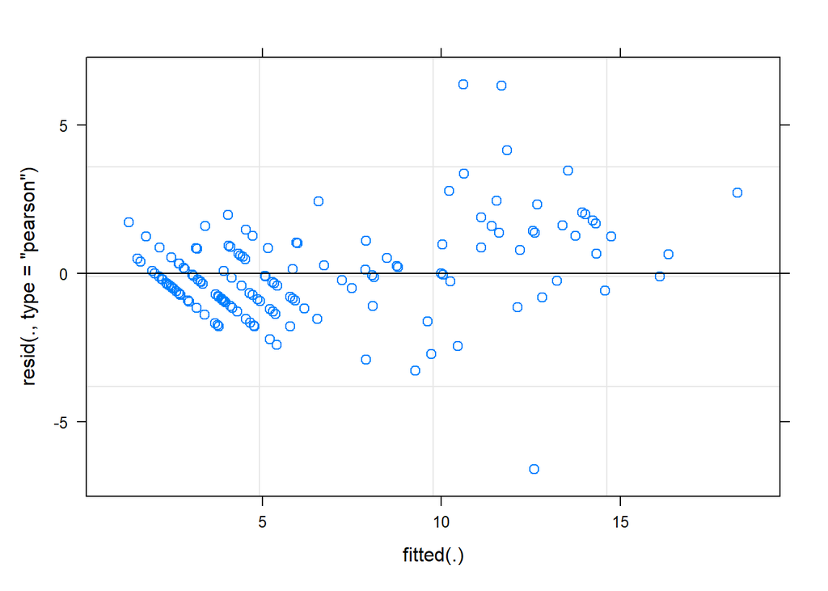

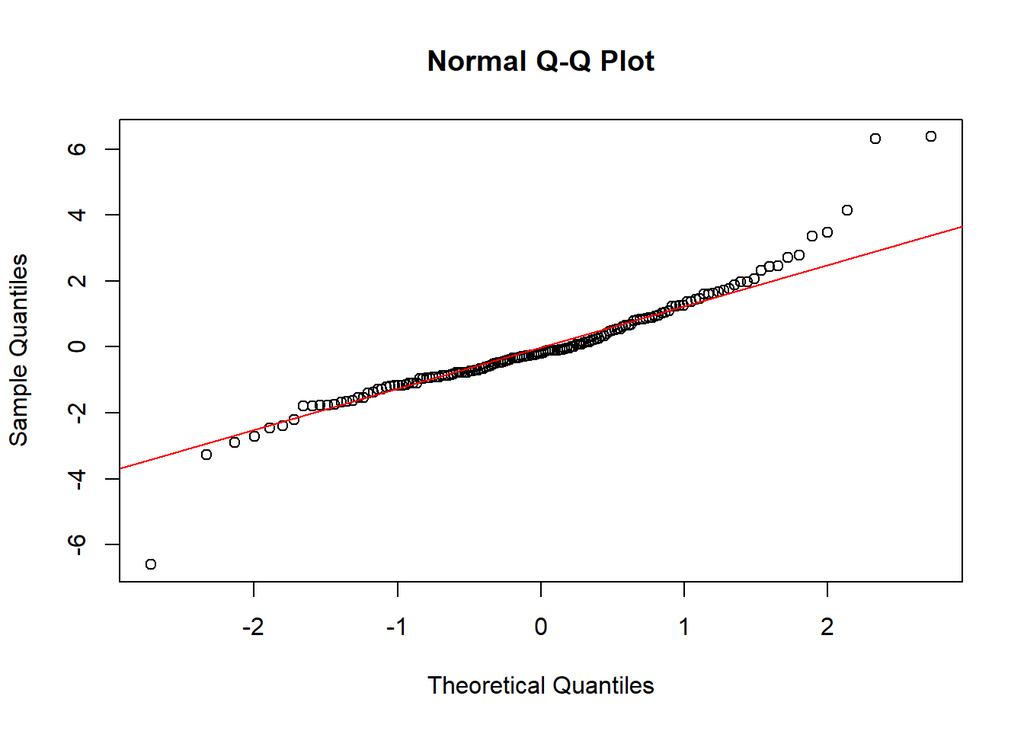

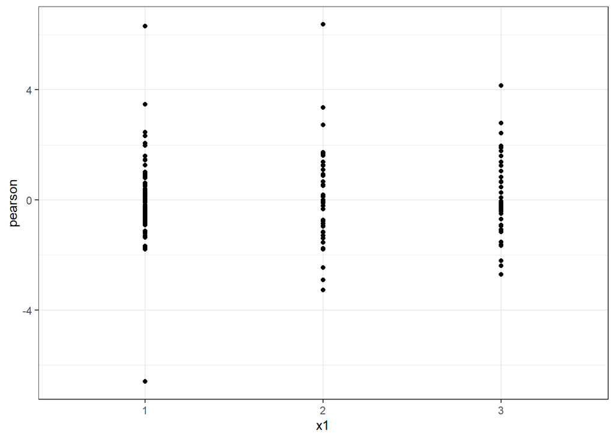

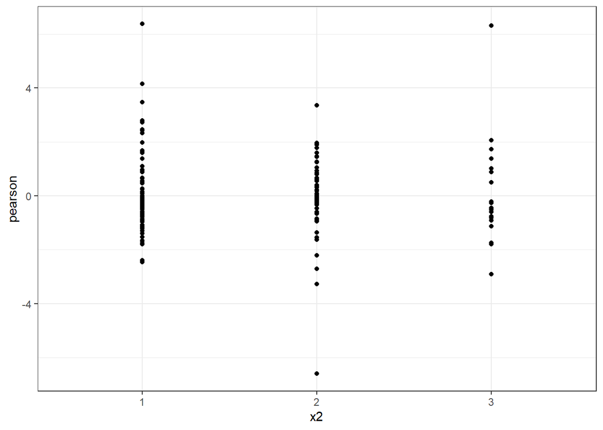

```r
rm(list = ls())
```